# Q1

```r
df = read.table("tips.txt",header = T)
df$tippercentage = 100*df$tip/df$total_bill
library(ggplot2)
```

```r
head(df)
```

| total_bill | tip | sex | smoker | day | time | size | tippercentage |
| --- | --- | --- | --- | --- | --- | --- | --- |
| 16.99 | 1.01 | Female | No | Sun | Dinner | 2 | 5.944673 |
| 10.34 | 1.66 | Male | No | Sun | Dinner | 3 | 16.054159 |
| 21.01 | 3.50 | Male | No | Sun | Dinner | 3 | 16.658734 |
| 23.68 | 3.31 | Male | No | Sun | Dinner | 2 | 13.978041 |
| 24.59 | 3.61 | Female | No | Sun | Dinner | 4 | 14.680765 |
| 25.29 | 4.71 | Male | No | Sun | Dinner | 4 | 18.623962 |

```r
summary(df$tippercentage)
```

```
   Min. 1st Qu.  Median    Mean 3rd Qu.    Max.
  3.564  12.913  15.477  16.080  19.148  71.034
```

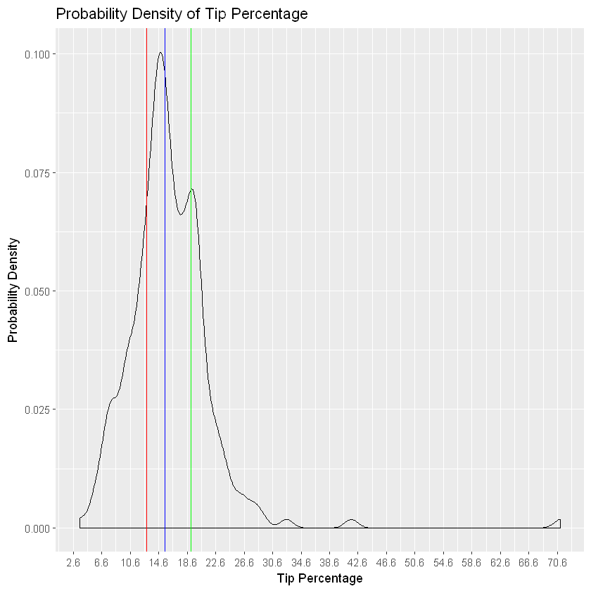

```r
ggplot(df,aes(x=tippercentage)) + geom_density(adjust=0.65) +
  geom_vline(xintercept= quantile(df$tippercentage,probs=c(0.25,0.5,0.75)),color=c("red","blue","green"))+
  scale_x_continuous(breaks = round(seq(min(df$tippercentage)-5, max(df$tippercentage)+5, by = 4),1)) +
  ylab("Probability Density") + xlab("Tip Percentage") + ggtitle("Probability Density of Tip Percentage")
```

• By observing the above plot it appears that the Tip Percentage is not normally distributed and is Right skewed.

• Since the data is right skewed mean is not an appropriate parameter to describe the center or spread of data.

• Redline – Q1 – 12.913

• Blueline – Median – 15.477

• We can clearly observe that (Median-Q1) ≠ (Q3-Median). Hence the data is not symmetric.

# Q2

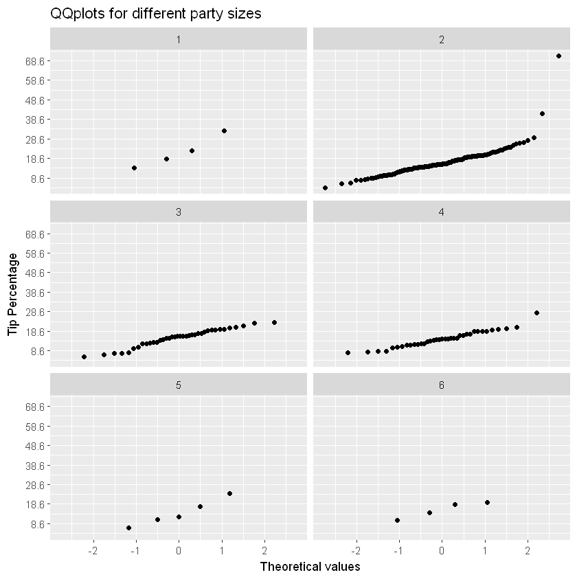

```r
ggplot(df, aes(sample = tippercentage)) + stat_qq() + facet_wrap(~size, ncol = 2)+
  scale_y_continuous(breaks = round(seq(min(df$tippercentage)-5, max(df$tippercentage)+5, by = 10),1)) +
  xlab("Theoretical values") + ylab("Tip Percentage") + ggtitle("QQplots for different party sizes")
```

• There is clearly not enough data for party sizes = 1,5 & 6 to make any interpretations.

• The distributions for the party sizes = 2,3 & 4 appear similar with their means centered around 15.

# Q3

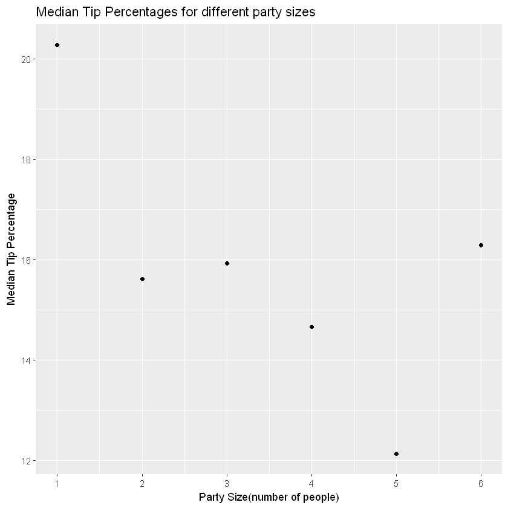

```r
df.medians = aggregate(tippercentage ~ size, FUN = "median", data = df)

ggplot(df.medians,aes(x=size,y=tippercentage))+geom_point()+
  scale_x_continuous(breaks=seq(0,7,1))+
  xlab("Party Size(number of people)")+
  ylab("Median Tip Percentage")+
  ggtitle("Median Tip Percentages for different party sizes")
```

• Since the data is not symmetric and with significant outliers Median is appropriate choice to describe the measure of center.

• For the party sizes = 2,3 & 4 the centers (medians) are around 15 and look real.

• For party size = 6 the center (median) is around 15 but it is only because of chance variation (do not have enough sample size)

• For party sizes = 1 & 5 the centers (medians) are extreme values (highest and lowest) but the sample sizes are not large enough to make any conclusions.